# CourseProject_Machine Learning

Laksmi Priya M

Thursday, January 22, 2015

## Summary:

The report summarises the development of a prediction model for predicting the class of exercise carried out based on various accelerometer measurements.The execrcises are classified into 5 different classes captured in the variable classe.I have used the method Random Forest for building the prediction method. This has given an accuracy of >99% for the testing set created.

## Analysis

```r
training<-read.csv("./pml-training.csv")
testing<-read.csv("./pml-testing.csv")
dim(training)
```

```
## [1] 19622   160
```

```r
library(caret)
```

The data has been downloaded from the source and saved into the working directory This data has been read into variables training and testing respectively. From the dimentions of the data we can note that the data has got 160 different variables, As this is a huge number of predictors, we need to preprocess the data to evaluate which variables to use for prediction

## Preprocessing:

Since the prediction algorithms cannot work with missing values, we have to check for any missing values in the data

```r
anyMissing<-sapply(training,is.na)
NAColumns<-apply(anyMissing,2,sum)
```

For further reducing the predictor count, variables with near zero variance have been checked using the function nsv, and these variables are removed from predictor list. As variables with near zero variance do not give any useful information about the output variable, they need not be included in the predictor list.

```r
training_sub<-subset(training,select=names(NAColumns[NAColumns==0]))
nsv<-nearZeroVar(training_sub)
training_sub<-training_sub[,-nsv]
str(training_sub)
```

```
## 'data.frame':    19622 obs. of  59 variables:
##  $ X                   : int  1 2 3 4 5 6 7 8 9 10 ...
##  $ user_name           : Factor w/ 6 levels "adelmo","carlitos",..: 2 2 2 2 2 2 2 2 2 2 ...
##  $ raw_timestamp_part_1: int  1323084231 1323084231 1323084231 1323084232 1323084232 1323084232 1323084232 1323084232 1323084232 1323084232 ...
##  $ raw_timestamp_part_2: int  788290 808298 820366 120339 196328 304277 368296 440390 484323 484434 ...
##  $ cvtd_timestamp      : Factor w/ 20 levels "02/12/2011 13:32",..: 9 9 9 9 9 9 9 9 9 9 ...
##  $ num_window          : int  11 11 11 12 12 12 12 12 12 12 ...
##  $ roll_belt           : num  1.41 1.41 1.42 1.48 1.48 1.45 1.42 1.42 1.43 1.45 ...
##  $ pitch_belt          : num  8.07 8.07 8.07 8.05 8.07 8.06 8.09 8.13 8.16 8.17 ...
##  $ yaw_belt            : num  -94.4 -94.4 -94.4 -94.4 -94.4 -94.4 -94.4 -94.4 -94.4 -94.4 ...
##  $ total_accel_belt    : int  3 3 3 3 3 3 3 3 3 3 ...
##  $ gyros_belt_x        : num  0 0.02 0 0.02 0.02 0.02 0.02 0.02 0.02 0.03 ...
##  $ gyros_belt_y        : num  0 0 0 0 0.02 0 0 0 0 0 ...
##  $ gyros_belt_z        : num  -0.02 -0.02 -0.02 -0.03 -0.02 -0.02 -0.02 -0.02 -0.02 0 ...
##  $ accel_belt_x        : int  -21 -22 -20 -22 -21 -21 -22 -22 -20 -21 ...
```

[output cut: 45 more lines]

from the summary we can also observe that columns 1:5 can be excluded from predictors As these are indicating index no, name and time stamp of when the activity was carried out and are unlikely to predict the outcome based on that. However we have plotted these first five columns against the output classe to enunciate the same

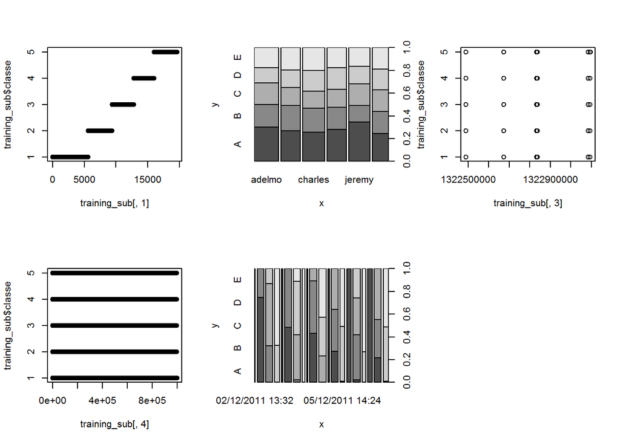

```r
par(mfrow=c(2,3))
plot(x=training_sub[,1],y=training_sub$classe)
plot(x=training_sub[,2],y=training_sub$classe)
plot(x=training_sub[,3],y=training_sub$classe)
plot(x=training_sub[,4],y=training_sub$classe)
plot(x=training_sub[,5],y=training_sub$classe)
```

A subset training1 is formed containing observations from only the predictor variables and the output variable

```r
training1<-training_sub[,-(1:5)]
```

## Subsetting Data for CrossValidation

It is important to performing cross validation in order to verify how the model will work for out of sample data. Hence the given training data has been divided into two subsets for training and testing the model. 70% of the observations are taken into trainng set and 30% of the observations are loaded into testing set.

```r
inTrain<-createDataPartition(y=training1$classe,p=0.7,list=FALSE)
training2<-training1[inTrain,]
test_trial<-training1[-inTrain,]
```

## building the model

As this is a classification problem with classe being a factor variable we can use the randomForest method for building the model. We have used the function from randomForest package instead of the train function in caret package, because train function resorts to default bootstrapping, which may take a very long time on a basic laptop.However crossvalidation carried out through bootstrapping in train function is expected to result in a greater accuracy.

```r
library(randomForest)
modelfit<-randomForest(classe~.,data=training2)
predicted<-predict(modelfit,training2)
confusionMatrix(predicted,training2$classe)
```

```
## Confusion Matrix and Statistics
##
##           Reference
## Prediction    A    B    C    D    E
##          A 3906    0    0    0    0
##          B    0 2658    0    0    0
##          C    0    0 2396    0    0
##          D    0    0    0 2252    0
##          E    0    0    0    0 2525
##
## Overall Statistics
##
##                Accuracy : 1
##                  95% CI : (0.9997, 1)
##     No Information Rate : 0.2843
##     P-Value [Acc > NIR] : < 2.2e-16
##
##                   Kappa : 1
##  Mcnemar's Test P-Value : NA
##
## Statistics by Class:
##
##                      Class: A Class: B Class: C Class: D Class: E
## Sensitivity            1.0000   1.0000   1.0000   1.0000   1.0000
## Specificity            1.0000   1.0000   1.0000   1.0000   1.0000
## Pos Pred Value         1.0000   1.0000   1.0000   1.0000   1.0000
## Neg Pred Value         1.0000   1.0000   1.0000   1.0000   1.0000
## Prevalence             0.2843   0.1935   0.1744   0.1639   0.1838
## Detection Rate         0.2843   0.1935   0.1744   0.1639   0.1838
## Detection Prevalence   0.2843   0.1935   0.1744   0.1639   0.1838
## Balanced Accuracy      1.0000   1.0000   1.0000   1.0000   1.0000
```

We can observe that, the accuracy is 100%, it is possible that the model is overfitted, which is one of the downsides of using the randomForest method for model building. We can also view the variable importance of different variables as shown below

```r
varImp(modelfit)
```

```
##                        Overall
## num_window           947.27348
## roll_belt            800.81419
## pitch_belt           441.91939
## yaw_belt             547.00208
## total_accel_belt     161.95109
## gyros_belt_x          58.86215
## gyros_belt_y          70.69865
## gyros_belt_z         185.65320
## accel_belt_x          82.82058
## accel_belt_y          91.86917
## accel_belt_z         282.90277
## magnet_belt_x        163.58001
## magnet_belt_y        230.67228
## magnet_belt_z        252.19058
## roll_arm             198.06753
## pitch_arm            110.38036
## yaw_arm              149.18136
## total_accel_arm       61.20542
## gyros_arm_x           76.93768
## gyros_arm_y           77.87269
## gyros_arm_z           35.10780
## accel_arm_x          148.15217
## accel_arm_y           86.91008
## accel_arm_z           80.37983
## magnet_arm_x         173.51001
## magnet_arm_y         143.92078
## magnet_arm_z         112.96332
## roll_dumbbell        265.33021
## pitch_dumbbell       124.23187
## yaw_dumbbell         173.59395
## total_accel_dumbbell 174.36542
## gyros_dumbbell_x      80.72411
## gyros_dumbbell_y     163.11373
## gyros_dumbbell_z      48.66917
## accel_dumbbell_x     167.91387
## accel_dumbbell_y     283.78771
## accel_dumbbell_z     218.70665
## magnet_dumbbell_x    315.45832
## magnet_dumbbell_y    449.24468
## magnet_dumbbell_z    492.84587
## roll_forearm         393.14312
## pitch_forearm        518.69917
## yaw_forearm           94.57676
## total_accel_forearm   60.33992
## gyros_forearm_x       43.48323
## gyros_forearm_y       77.20862
## gyros_forearm_z       49.00386
## accel_forearm_x      203.70232
## accel_forearm_y       85.13429
## accel_forearm_z      156.80059
## magnet_forearm_x     141.96726
## magnet_forearm_y     133.69691
## magnet_forearm_z     171.85484
```

Highest correlated variable is shown as num_window.

## Cross Validation

We have tested the model against the testing data set created by us for cross validation. The out of sample error rate for this is expected to be higher than the insample error rate which is 0%.

```r
predict_test<-predict(modelfit,test_trial)
confusionMatrix(predict_test,test_trial$classe)
```

```
## Confusion Matrix and Statistics
##
##           Reference
## Prediction    A    B    C    D    E
##          A 1674    2    0    0    0
##          B    0 1137    4    0    0
##          C    0    0 1022    6    0
##          D    0    0    0  958    2
##          E    0    0    0    0 1080
##
## Overall Statistics
##
##                Accuracy : 0.9976
##                  95% CI : (0.996, 0.9987)
##     No Information Rate : 0.2845
##     P-Value [Acc > NIR] : < 2.2e-16
##
##                   Kappa : 0.997
##  Mcnemar's Test P-Value : NA
##
## Statistics by Class:
##
##                      Class: A Class: B Class: C Class: D Class: E
## Sensitivity            1.0000   0.9982   0.9961   0.9938   0.9982
## Specificity            0.9995   0.9992   0.9988   0.9996   1.0000
## Pos Pred Value         0.9988   0.9965   0.9942   0.9979   1.0000
## Neg Pred Value         1.0000   0.9996   0.9992   0.9988   0.9996
## Prevalence             0.2845   0.1935   0.1743   0.1638   0.1839
## Detection Rate         0.2845   0.1932   0.1737   0.1628   0.1835
## Detection Prevalence   0.2848   0.1939   0.1747   0.1631   0.1835
## Balanced Accuracy      0.9998   0.9987   0.9974   0.9967   0.9991
```

This indicates a 99.8% accuracy. Hence the out of sample error rate is 0.2%. Which is as expected higher than the insample error rate.